# Introduction to Data Mathematics Spring 2021

PreLab 2: K-Means

Jared Gridley

# Lab Overview

In this prelab, you will learn how to read in data set from a file, prepare it for processing and analyze it with k-means.Specifically, you will:

- Read in a `csv` file
- Prepare data for analysis
- “Sanity check” your data
- Use k-means to identify clusters
- Select a number of clusters
- Intepret your clusters using various plot formats

In this prelab we will demonstrate the techniques using a “toy” data set from class. The questions listed as $\color{blue}{Exercise}$ will be graded, so be sure you have answered them in your final submission!

We recommend you start by saving this prelab `PreLab2.Rmd` to your local `IDM_work` directory, edit the header to include your name, and then “knit” it for practice.

# Setting up the Prelab

Copy `PreLab2.Rmd` to your working directory `IDM_work`. Use this for your assignment. Do a practice “knit” (to pdf or html) before you begin.

# Do K-means Analysis

Let’s begin by repeating the k-means analyses covered in class.

## Read in and Explore the Data Set

First, we need to get the dataset ready for analysis.

```r
# Read in data from the data file; create a dataframe
M.df <- read.csv("~/MATP-4400/data/lab2dat.csv")

# Examine the data by using the str() command
str(M.df)
```

```
## 'data.frame':    20 obs. of  3 variables:
##  $ Length: num  -2.3577 -2.6955 0.626 -0.0242 -0.3385 ...
##  $ Width : num  -1.133 -0.362 0.473 -0.605 -0.841 ...
##  $ Height: num  -0.64084 0.00582 -0.06637 -0.60266 -1.91596 ...
```

```r
# Convert the dataframe to a matrix
M.matrix <-as.matrix(M.df)
```

```r
# Compute the column means
colMeans(M.matrix)
```

```
##    Length     Width    Height
## 1.3940908 1.1740241 0.7642641
```

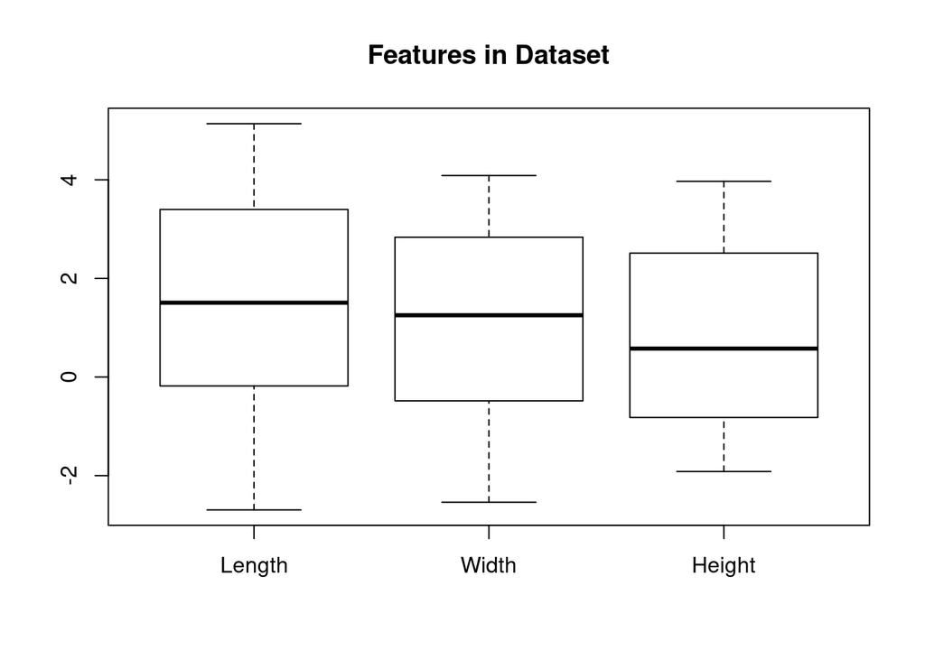

```r
boxplot(M.matrix, main="Features in Dataset")
```

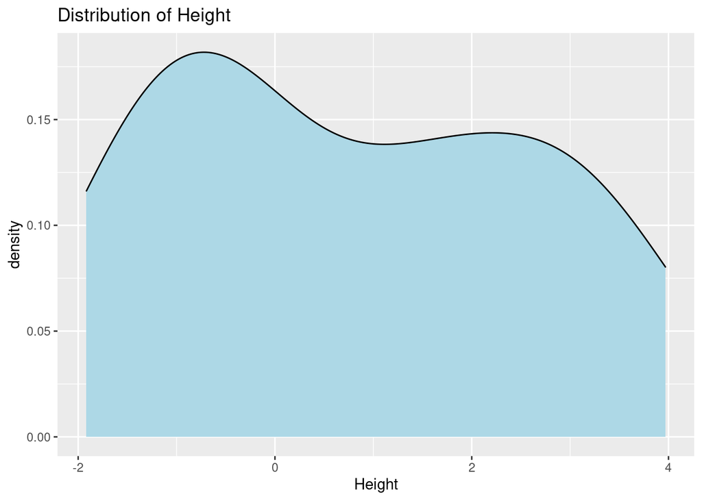

```r
# make densities plots of the Height of a matrix
#  use ggplot in M.df using Height variable
ggplot(M.df,aes(x=Height)) +
  geom_density(fill="light blue") + # The density plot is filled with light blue
  ggtitle("Distribution of Height") #b Give it a title
```

Notice the structure of the `ggplot()` command:

- `ggplot(M.df,aes(x=Height)) +` starts the plot and says to use the data.frame `M.df`, and to use `Height` as the x-axis valiable. `ggplot()` only works on data frames and produces a *plot object*. The `aes()` function (“aesthetic”) is used to specify variables and options to use when constructing ggplot objects and adding geometry layers.
- The `+` adds *layers* to the ggplot object.
- `geom_density(fill="light blue") +` specifies a “geometry” for the plot (a *density* plot); `fill="light blue"` instructs gpplot to fill the resulting density plot to a fixed value, in this case `light blue`.
- `ggtitle()` specifies the title of the plot.

To learn more about `geom_density()`, check out this link (http://www.sthda.com/english/wiki/ggplot2-density-plot-quick-start-guide-r-software-and-data-visualization) and/or type `?geom_density` in your R console.

**TRY IT:** Make additional density plots of the `Length` and `Width` of the matrix. Receive an extra point, if you add features beyond the simple density plot we created above.

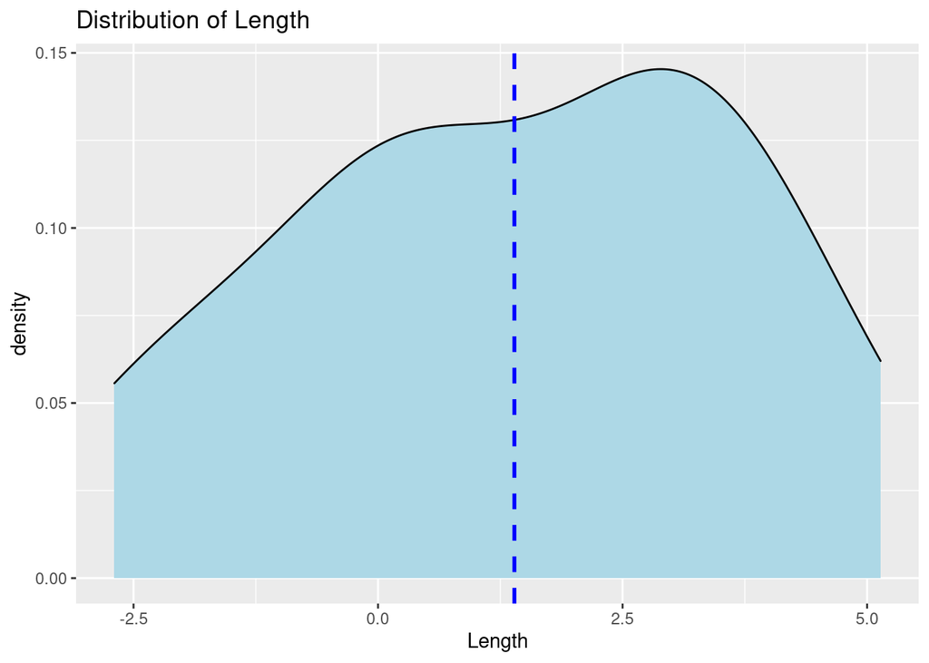

```r
#Plot of the length with the mean line
L_plot <- ggplot(M.df, aes(x=Length)) + geom_density(fill = "lightblue") + geom_vline(aes(xintercept=mean(Length)), linetype = "dashed", size = 1, color = "blue") + ggtitle("Distribution of Length")
L_plot
```

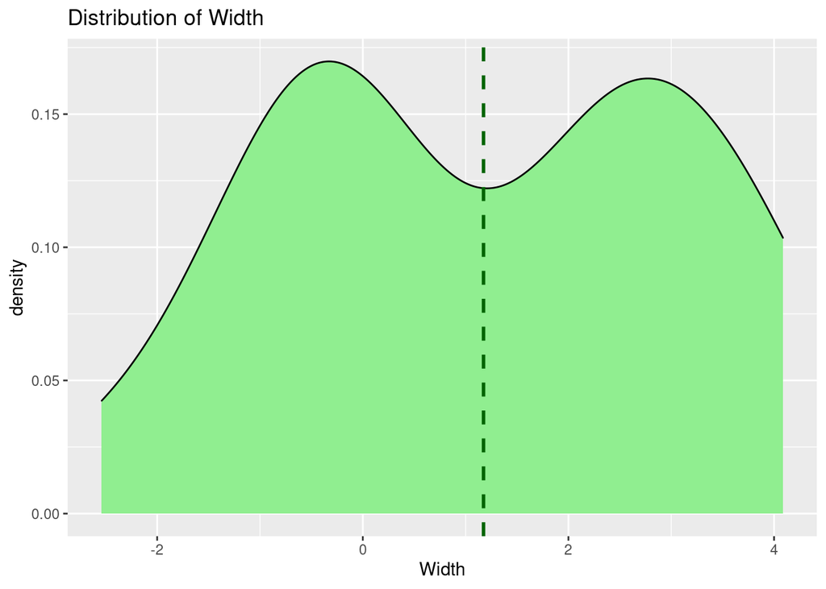

```r
#Width plot with the mean line
W_plot <- ggplot(M.df, aes(x=Width)) + geom_density(fill = "lightgreen") + geom_vline(aes(xintercept=mean(Width)), linetype = "dashed", size = 1, color = "darkgreen") + ggtitle("Distribution of Width")
W_plot
```

## Make a heatmap of the data

NOTE: The `heatmap.2()` function only works on matrices!

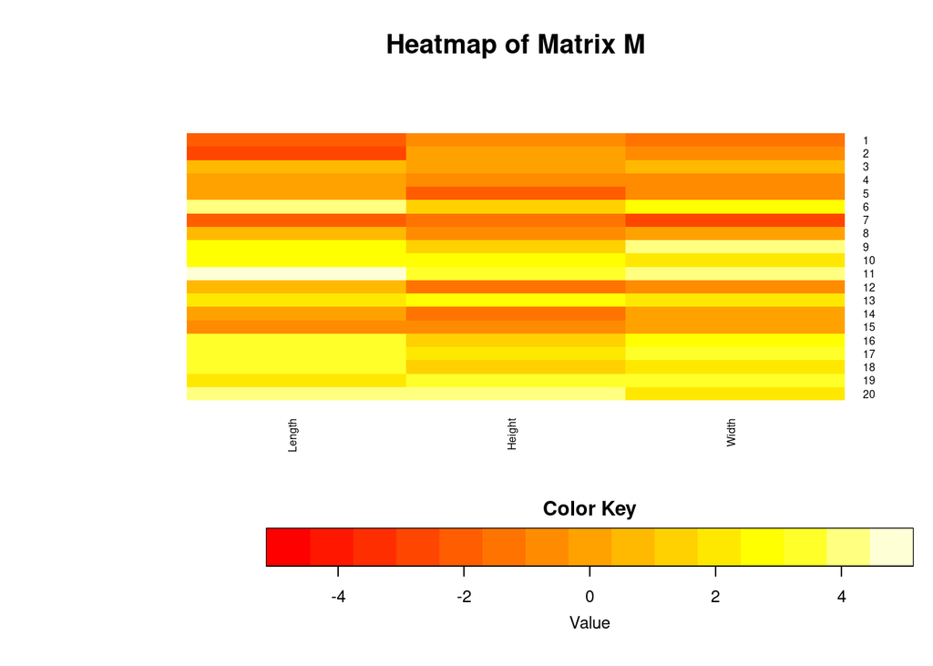

```r
# First set up the heatmap layout (key on bottom)
lmat = rbind(c(0,3),
            c(2,1),
            c(0,4))
lwid = c(1,4)
lhei = c(1.5,4,2)

# The options we've shown ensure that the heatmap is for the matrix as-is without any rescaling or reordering.
heatmap.2(M.matrix, main='Heatmap of Matrix M',
          dendrogram="none",
          Rowv=FALSE,  # Keep rows as is
          cexRow=0.75, # this makes the text smaller
          cexCol=0.75,
          scale="none", # Don't rescale data
          tracecol=NA,
          density.info='none',
          lmat=lmat, lwid = lwid, lhei = lhei
          )
```

## Create K-means Clusters

Now we introduce a function for creating k-means plots. The basic k-means function is `kmeans(D.matrix, centers =k)` in which `D.matrix` is a matrix of data and `k` is the number of clusters.

Here is an example for `k=4`:

```r
kmResult.df <- kmeans(M.matrix, centers = 4)
```

The outputs are found in `kmResult.df`.

```r
# Assignment of points to vectors
kmResult.df$cluster
```

```
##  [1] 4 4 3 3 1 2 4 1 2 2 2 1 2 1 3 2 2 2 2 2
```

```r
# Cluster Centers
str(kmResult.df$center)
```

```
##  num [1:4, 1:3] 0.384 3.334 -0.069 -2.262 -0.402 ...
##  - attr(*, "dimnames")=List of 2
##   ..$ : chr [1:4] "1" "2" "3" "4"
##   ..$ : chr [1:3] "Length" "Width" "Height"
```

```r
# Objective Function
kmResult.df$tot.withinss
```

```
## [1] 29.69704
```

# Choose K

Now, we create a function to examine cluster sizes. The function below takes as its arguments a matrix, the maximum number of clusters and a random seed.

The basic syntax for creating a user-defined function in R is: `output <- function(arguments){ do stuff}`

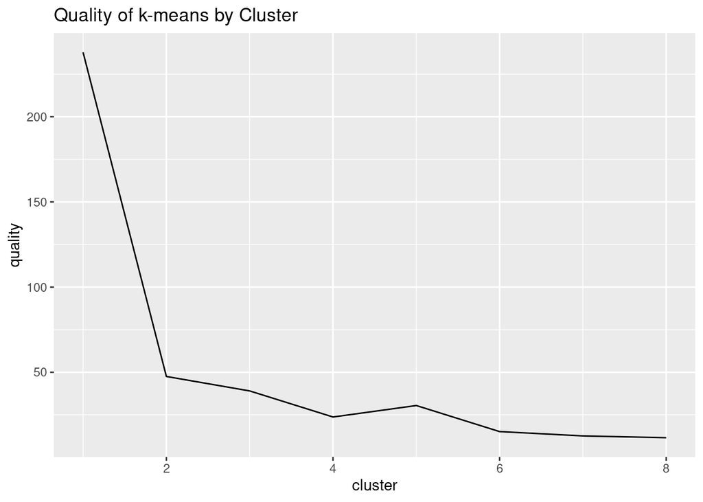

```r
# A user-defined function to examine clusters and plot the results
wssplot <- function(data, nc=15, seed=10){
  wss <- data.frame(cluster=1:nc, quality=c(0))
  for (i in 1:nc){
    set.seed(seed)
    wss[i,2] <- kmeans(data, centers=i)$tot.withinss}
  ggplot(data=wss,aes(x=cluster,y=quality)) +
    geom_line() +
    ggtitle("Quality of k-means by Cluster")
}
# Generate the plot
wssplot(M.matrix, nc=8)
```

This function calculates k-means solutions for k= 1 to nc. In this code, `nc=8`.  
Then, it plots a line chart of the *Sum of Square Errors (SSE)* for each value of k. If the line chart looks like an arm, then the “elbow” on the arm is the value of k that is the best. The idea is that we want a small SSE, but that the SSE tends to decrease toward 0 as we increase k (the SSE is 0 when k is equal to the number of data points in the dataset, because then each data point is its own cluster, and there is no error between it and the center of its cluster). So our goal is to choose a small value of k that still has a low SSE, and the elbow usually represents where we start to have diminishing returns by increasing k.

In this case, it looks like `k=2` is the best choice, since there is a clear “elbow” at 2. Considering this, we rerun k-means to obtain the final clustering and then plot with respect to two variables.

```r
# set the random see to be 10
set.seed(10)
km <- kmeans(M.matrix,centers=2)
```

The variable `km` contains the results of the k-means clustering.

```r
str(km)
```

```
## List of 9
##  $ cluster     : int [1:20] 2 2 2 2 2 1 2 2 1 1 ...
##  $ centers     : num [1:2, 1:3] 3.334 -0.546 2.924 -0.576 2.403 ...
##   ..- attr(*, "dimnames")=List of 2
##   .. ..$ : chr [1:2] "1" "2"
##   .. ..$ : chr [1:3] "Length" "Width" "Height"
##  $ totss       : num 238
##  $ withinss    : num [1:2] 21.7 25.8
##  $ tot.withinss: num 47.5
##  $ betweenss   : num 190
##  $ size        : int [1:2] 10 10
##  $ iter        : int 1
##  $ ifault      : int 0
##  - attr(*, "class")= chr "kmeans"
```

## Analyze the results

Let’s explore the results

```r
# Here are the cluster centers
km$centers
```

```
##       Length      Width    Height
## 1  3.3338467  2.9242280  2.403324
## 2 -0.5456652 -0.5761798 -0.874796
```

First let’s plot each point in the Length x Height space using ‘ggplot’ and the ‘geom_point’ function.

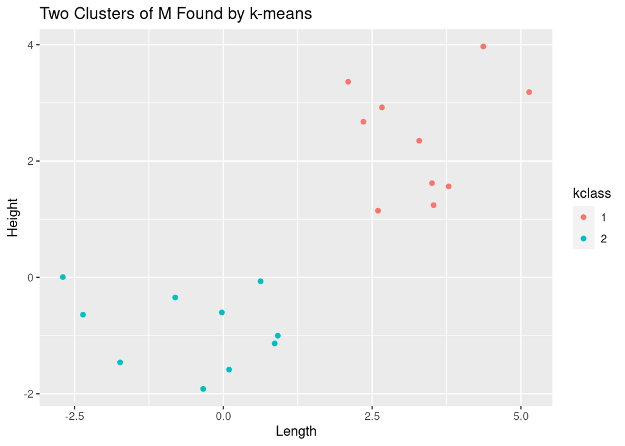

```r
# Convert the cluster vector to a factor
kclass=as.factor(km$cluster)
# Make a data frame with the data and the results
kclass=as.factor(km$cluster)
Mresults.df <-cbind.data.frame(M.matrix,kclass)

# call ggplot with Mdf
ggplot(data=Mresults.df,aes(x=Length, y=Height,color=kclass)) +
# plot point on length versus height graph colored by kclass
  geom_point() +
  ggtitle('Two Clusters of M Found by k-means')
```

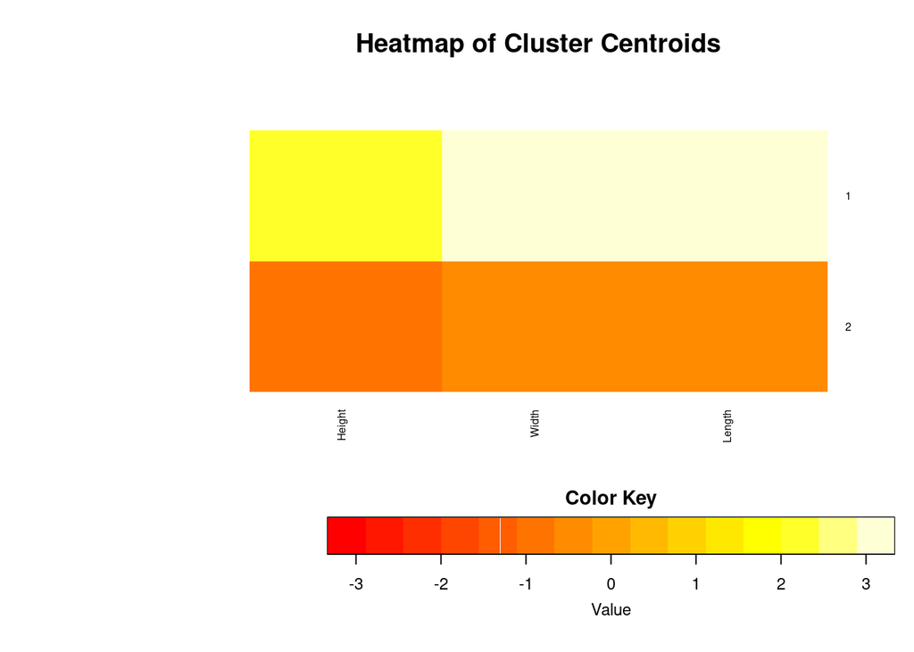

```r
# First set up the heatmap layout (key on bottom)
lmat = rbind(c(0,3),
            c(2,1),
            c(0,4))
lwid = c(1.5,4)
lhei = c(1.5,4,2)

# generate the heatmap of the cluster centers
heatmap.2(km$centers,
          dendrogram='none',
          main='Heatmap of Cluster Centroids',
          cexRow=0.75,
          cexCol=0.75,
          Rowv=FALSE,
          scale = 'none',
          tracecol=NA,
          density.info='none',
           # label cells with values
          lmat=lmat, lwid = lwid, lhei = lhei
          )
```

## What patterns in the cluster centers do you see?

Explore differences in the data values using [boxplots](http://www.physics.csbsju.edu/stats/box2.html) by looking at the boxplot of `Length` by cluster. Note that the formula `Length~kclass` specifies that `boxplot()` should make boxplots of `Length` grouped by `kclass`.

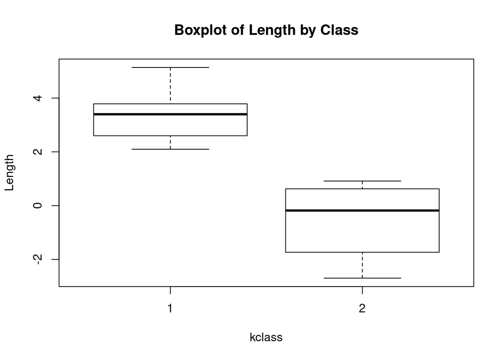

```r
boxplot(Length~kclass, data=Mresults.df, main="Boxplot of Length by Class")
```

Make a density plot of `Length` by `kclass`:

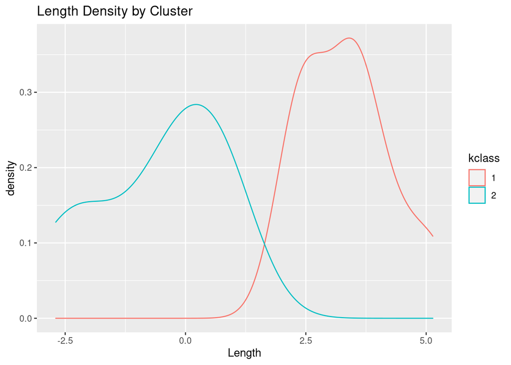

```r
ggplot(data=Mresults.df) +
  geom_density(aes(Length, color=kclass)) +
  ggtitle("Length Density by Cluster")
```

# $\color{blue}{Exercise\ 1:}$

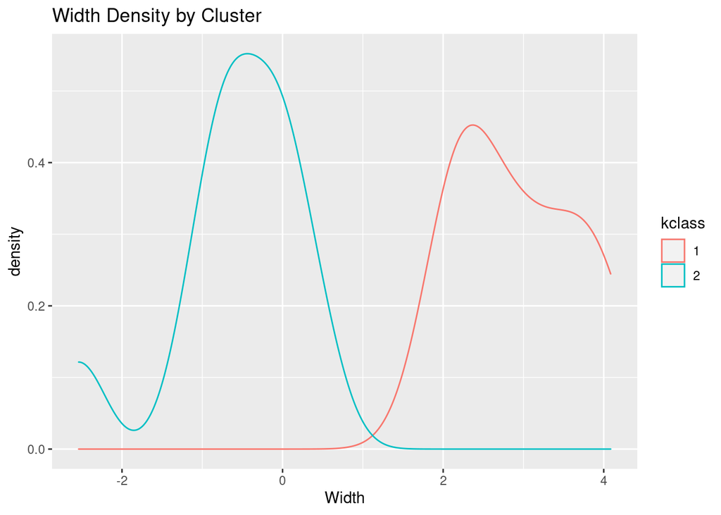

```r
#Width Density graph
ggplot(data=Mresults.df) +
  geom_density(aes(Width, color=kclass)) +
  ggtitle("Width Density by Cluster")
```

```r
cluster1 <- M.df[kclass==1,]
print("Summary of cluster 1 (with column mean)")
```

```
## [1] "Summary of cluster 1 (with column mean)"
```

```r
summary(cluster1)
```

```
##      Length          Width           Height
##  Min.   :2.098   Min.   :2.032   Min.   :1.146
##  1st Qu.:2.616   1st Qu.:2.259   1st Qu.:1.578
##  Median :3.398   Median :2.835   Median :2.512
##  Mean   :3.334   Mean   :2.924   Mean   :2.403
##  3rd Qu.:3.723   3rd Qu.:3.550   3rd Qu.:3.119
##  Max.   :5.138   Max.   :4.087   Max.   :3.969
```

```r
cluster2 <- M.df[kclass==2,]
print("Summary of cluster 2 (with mean)")
```

```
## [1] "Summary of cluster 2 (with mean)"
```

```r
summary(cluster2)
```

```
##      Length            Width             Height
##  Min.   :-2.6955   Min.   :-2.5396   Min.   :-1.91596
##  1st Qu.:-1.5026   1st Qu.:-0.8060   1st Qu.:-1.37983
##  Median :-0.1813   Median :-0.4834   Median :-0.82122
##  Mean   :-0.5457   Mean   :-0.5762   Mean   :-0.87480
##  3rd Qu.: 0.4938   3rd Qu.:-0.0316   3rd Qu.:-0.40956
##  Max.   : 0.9157   Max.   : 0.4735   Max.   : 0.00582
```

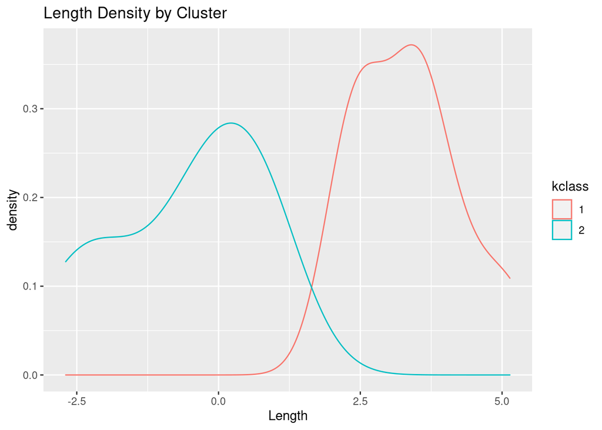

```r
#Length Density graph
ggplot(data=Mresults.df) +
  geom_density(aes(Length, color=kclass)) +
  ggtitle("Length Density by Cluster")
```

**You’ve now completed Prelab2! Go to LMS and complete the online quiz**

[output not shown]